# Relación entre las horas de sueño, el uso de Inteligencia Artificial y el rendimiento académico de los estudiantes de Estadística y Probabilidades 1, sección 1 durante el ciclo 2026-2

Variables aleatorias discretas y continuas | Estadística y Probabilidades I - Sección 1

Cristóbal Aranda · Pedro Chávez · Joaquín Temoche · Eden Paredes · Néstor de la Cruz

2026-11-06

## Muestra efectiva

Se utilizan las observaciones limpias de **toda la sección 1**, ciclo 2026-2.

| Formulario | Variable de estudio | Registros válidos |
| --- | --- | --- |
| Diario | Consultas a IA | 984 |
| Diario | Horas de sueño | 984 |
| Demográfico | Créditos académicos | 47 |
| Exámenes | Nota obtenida | 207 |

Se quitaron filas exactamente duplicadas, valores faltantes y valores imposibles según la escala de cada variable. Cada registro corresponde a una respuesta; puede haber varios registros de una misma persona.

## Variable discreta 1: consultas a IA

**Caso:** ¿Cuál es la probabilidad de que la primera respuesta con **más de 10 consultas a IA en el día** aparezca en la vigésima selección?

**Variable aleatoria:** $X =$ número de respuestas diarias seleccionadas hasta encontrar la primera con más de 10 consultas.

- Distribución: $X \sim Geom(p)$, contando desde 1.
- Éxito: la respuesta indica más de 10 consultas.
- $p = P(\text{más de 10 consultas}) = \frac{\text{respuestas con más de 10 consultas}}{\text{respuestas válidas}}$.
- Con los datos: $p =$ 0.361 (36.08%).

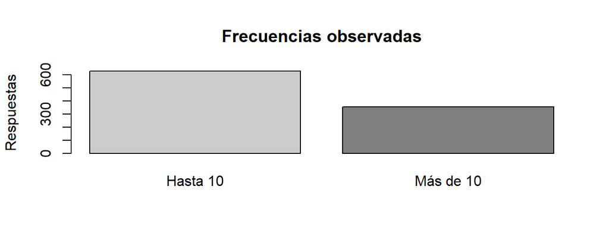

## Discreta 1: distribución y resultados

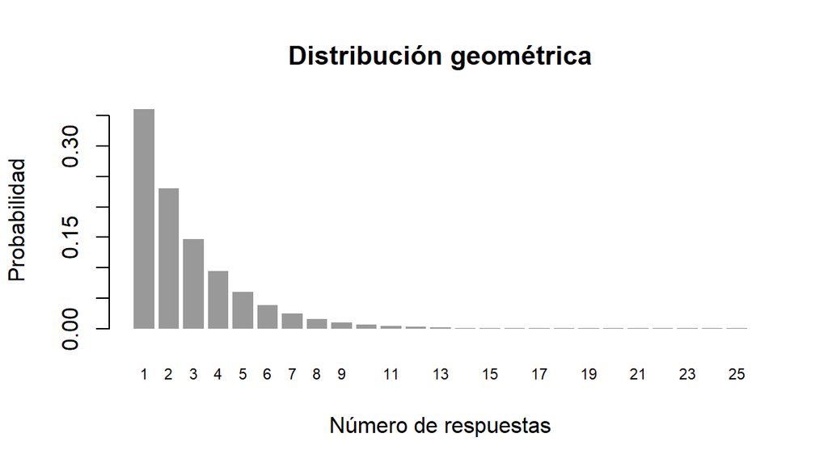

$P(X=k)=(1-p)^{k-1}p,\ k=1,2,\dots$

$E(X)=1/p =$ 2.772

$V(X)=(1-p)/p^2 =$ 4.911

$SD(X)=$ 2.216

$CV(X)=$ 79.95%

**Probabilidad solicitada**

$P(X=20)=(1-p)^{19}p =$ **0.01%**

**Acumulada:** $P(X<20)=P(X\leq 19) =$ 99.98%.

En R: `dgeom(19, p1)` y `pgeom(18, p1)`.

## Variable discreta 2: créditos académicos

**Caso:** Si se eligen 10 registros demográficos de forma independiente y con reemplazo, ¿cuál es la probabilidad de que exactamente 7 correspondan a estudiantes con **20 créditos o más**?

**Variable aleatoria:** $Y =$ cantidad de registros, entre 10 seleccionados, con al menos 20 créditos.

- Distribución: $Y \sim Binomial(n=10,p)$.
- Éxito: registrar una carga académica de 20 créditos o más.
- $p = P(\text{créditos} \geq 20) =$ 0.447 (44.68%).

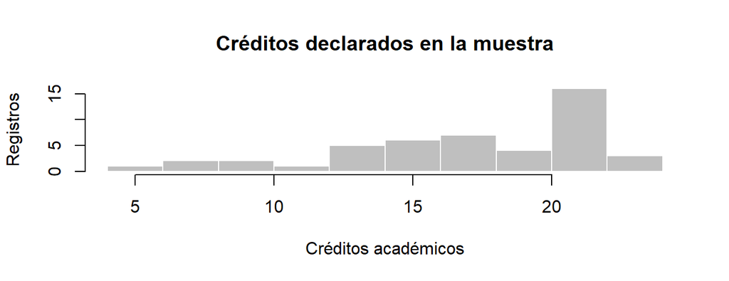

## Discreta 2: distribución y resultados

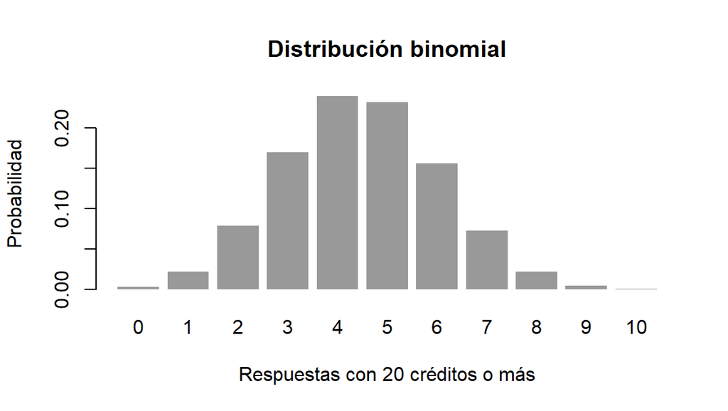

$P(Y=y)=\binom{10}{y}p^y(1-p)^{10-y},\ y=0,\dots,10$

$E(Y)=np =$ 4.468

$V(Y)=np(1-p) =$ 2.472

$SD(Y)=$ 1.572

$CV(Y)=$ 35.19%

**Probabilidad solicitada**

$P(Y=7)=\binom{10}{7}p^7(1-p)^3 =$ **7.22%**

**Acumulada:** $P(Y\geq 7) =$ 9.83%.

En R: `dbinom(7, 10, p2)` y `pbinom(6, 10, p2, lower.tail = FALSE)`.

## Variable continua 1: horas de sueño

**Variable aleatoria:** $H =$ horas dormidas la noche anterior, registradas en el formulario diario.

Se evalúa una aproximación normal mediante histograma, curva ajustada y gráfico de cuantiles.

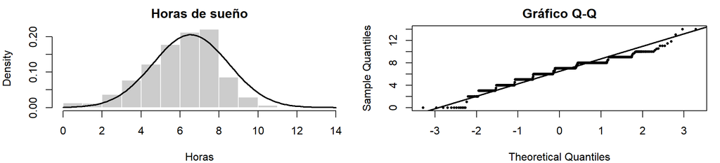

Media: 6.55 h. Mediana: 7 h. Desviación: 1.939 h. Asimetría: -0.468.  
Shapiro-Wilk: $p < 0.001$; se rechaza la normalidad al 5%.

**Validación:** media y mediana cercanas, asimetría moderada y forma de campana; el Q-Q sigue la recta en el centro y se separa en los extremos. Se acepta la normal como aproximación (**caso 2**).

## Continua 1: propiedades y ejemplo

Para el ejemplo se usa el modelo teórico $H \sim N(\mu,\sigma^2)$, con parámetros estimados:

- $\mu =$ 6.55 horas y $\sigma =$ 1.939 horas.
- $E(H)=\mu =$ 6.55 horas.
- $V(H)=\sigma^2 =$ 3.759 horas$^2$.
- $SD(H)=\sigma =$ 1.939 horas.
- $CV(H)=\sigma/\mu =$ 29.6%.

**Caso:** ¿Cuál es la probabilidad de que una respuesta elegida al azar registre entre 6 y 8 horas de sueño?

$P(6 \leq H \leq 8)=F(8)-F(6) =$ **38.44%**.

**Ejemplo acumulado:** $P(H \leq 7) =$ 59.17%.

En R: `pnorm(8, mu_h, sd_h) - pnorm(6, mu_h, sd_h)`.

## Variable continua 2: nota de examen

**Variable aleatoria:** $T =$ nota registrada de un examen, en escala de 0 a 20.

Se evalúa una aproximación normal con el histograma y el gráfico Q-Q.

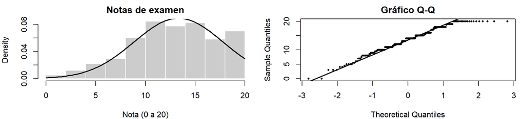

Media: 13.317. Mediana: 14. Desviación: 4.477. Asimetría: -0.426.  
Shapiro-Wilk: $p < 0.001$; se rechaza la normalidad al 5%.

**Validación:** media y mediana cercanas, Q-Q aceptable en el centro, pero con asimetría negativa y acumulación en 20 (6.92% fuera de 0 a 20). Se usa la normal como aproximación (**caso 2**).

## Continua 2: propiedades y ejemplo

Para el ejemplo se usa el modelo teórico $T \sim N(\mu,\sigma^2)$, con parámetros estimados:

- $\mu =$ 13.317 puntos y $\sigma =$ 4.477 puntos.
- $E(T)=\mu =$ 13.317 puntos.
- $V(T)=\sigma^2 =$ 20.043 puntos$^2$.
- $SD(T)=\sigma =$ 4.477 puntos.
- $CV(T)=\sigma/\mu =$ 33.62%.

**Caso:** ¿Cuál es la probabilidad de obtener una nota de al menos 14 puntos?

$P(T\geq 14)=1-F(14) =$ **43.94%**.

**Ejemplo de intervalo:** $P(10\leq T\leq 16) =$ 49.61%.

En R: `pnorm(14, mu_n, sd_n, lower.tail = FALSE)`.

## Comparación de las cuatro variables

| Variable aleatoria | Modelo | Resultado del ejemplo |
| --- | --- | --- |
| $X$: respuestas hasta primera con más de 10 consultas | Geométrica | 0.01% |
| $Y$: registros con 20 o más créditos entre 10 | Binomial | 7.22% |
| $H$: horas dormidas entre 6 y 8 | Normal aproximada | 38.44% |
| $T$: nota mayor o igual que 14 | Normal aproximada | 43.94% |

Los dos casos discretos utilizan **consultas** y **créditos**. Los dos casos continuos utilizan **horas de sueño** y **notas de examen**. Cada variable aleatoria y cada caso son diferentes.

## Conclusiones y consideraciones

- Los parámetros de las cuatro distribuciones se estimaron con las observaciones limpias disponibles de toda la sección.
- Los modelos geométrico y binomial suponen selecciones independientes, por lo que las probabilidades son teóricas y aproximadas.
- Las dos normales son modelos para desarrollar los ejemplos; los histogramas, Q-Q y Shapiro-Wilk permiten evaluar si son aproximaciones razonables.
- Las notas solo pueden tomar valores entre 0 y 20. El modelo normal asigna 6.92% fuera de ese intervalo, lo cual constituye una limitación.
- Los registros repetidos de un estudiante no equivalen a estudiantes distintos, y las respuestas no permiten afirmar causalidad.

**Fuente de datos:** formularios diario, demográfico y de exámenes, Estadística y Probabilidades I, sección 1, ciclo 2026-2.